# Ridge y Lasso en R

# 1. Introducción

- Ridge y Lasso son extensiones del modelo de regresión lineal que atacan los problemas de la alta dimensionalidad (muchas variables frente al número de observaciones): alta varianza en las predicciones y dificultad de interpretación.
- Ambos introducen una **penalidad** sobre el tamaño de los coeficientes, halándolos hacia 0.
- Bajo **Ridge** los coeficientes tienden a 0 a medida que pesa más la penalidad, pero nunca son exactamente 0.
- Bajo **Lasso** algunos coeficientes sí se vuelven exactamente 0.
- La clave es la elección del parámetro $\lambda$, que mide el peso de la penalidad.

# 2. Datos

- Trabajaremos con `Hitters.csv`: información sobre el salario de un conjunto de beisbolistas en EE.UU. Queremos predecir el salario en función de sus características.
- Leemos la base (con `stringsAsFactors = TRUE` para las variables categóricas como `League` o `Division`):

```r
hitters <- read.csv("data/Hitters.csv", stringsAsFactors = TRUE)
str(hitters)
```

```
## 'data.frame':    322 obs. of  21 variables:
##  $ X        : Factor w/ 322 levels "-Al Newman","-Alan Ashby",..: 12 2 7 8 10 6 1 14 11 9 ...
##  $ AtBat    : int  293 315 479 496 321 594 185 298 323 401 ...
##  $ Hits     : int  66 81 130 141 87 169 37 73 81 92 ...
##  $ HmRun    : int  1 7 18 20 10 4 1 0 6 17 ...
##  $ Runs     : int  30 24 66 65 39 74 23 24 26 49 ...
##  $ RBI      : int  29 38 72 78 42 51 8 24 32 66 ...
##  $ Walks    : int  14 39 76 37 30 35 21 7 8 65 ...
##  $ Years    : int  1 14 3 11 2 11 2 3 2 13 ...
##  $ CAtBat   : int  293 3449 1624 5628 396 4408 214 509 341 5206 ...
##  $ CHits    : int  66 835 457 1575 101 1133 42 108 86 1332 ...
##  $ CHmRun   : int  1 69 63 225 12 19 1 0 6 253 ...
##  $ CRuns    : int  30 321 224 828 48 501 30 41 32 784 ...
##  $ CRBI     : int  29 414 266 838 46 336 9 37 34 890 ...
##  $ CWalks   : int  14 375 263 354 33 194 24 12 8 866 ...
##  $ League   : Factor w/ 2 levels "A","N": 1 2 1 2 2 1 2 1 2 1 ...
##  $ Division : Factor w/ 2 levels "E","W": 1 2 2 1 1 2 1 2 2 1 ...
##  $ PutOuts  : int  446 632 880 200 805 282 76 121 143 0 ...
##  $ Assists  : int  33 43 82 11 40 421 127 283 290 0 ...
##  $ Errors   : int  20 10 14 3 4 25 7 9 19 0 ...
##  $ Salary   : num  NA 475 480 500 91.5 750 70 100 75 1100 ...
##  $ NewLeague: Factor w/ 2 levels "A","N": 1 2 1 2 2 1 1 1 2 1 ...
```

- La primera columna son los nombres; no nos interesa, la eliminamos:

```r
hitters <- hitters[, -1]
```

- Queremos predecir el salario. Nótese que hay valores ausentes (*missing*) en `Salary`:

```r
sum(is.na(hitters$Salary))
```

```
## [1] 59
```

- Para Ridge y Lasso debemos eliminar esas observaciones (como en el enfoque OLS tradicional):

```r
hitters <- na.omit(hitters)
sum(is.na(hitters))
```

```
## [1] 0
```

- Quedamos con 263 observaciones. Para correr Ridge y Lasso usamos el paquete `glmnet`. Si no lo tienes instalado:

```r
install.packages("glmnet")
```

```r
library(glmnet)
```

- La sintaxis de `glmnet` es distinta: hay que construir la matriz de atributos con `model.matrix()` (que además crea las *dummies* de las categóricas) y el vector de *outcomes*:

```r
x <- model.matrix(Salary ~ ., hitters)[, -1]
y <- hitters$Salary
```

# 3. Regresión Ridge

- En `glmnet()`, el parámetro `alpha` define el modelo: `alpha = 0` es Ridge y `alpha = 1` es Lasso.
- También definimos una grilla de valores de $\lambda$, desde valores enormes (modelo casi sin predictores) hasta cercanos a 0 (OLS). Creamos 100 valores:

```r
grid <- 10^seq(10, -2, length = 100)
```

- Estimamos los 100 modelos Ridge (uno por cada $\lambda$):

```r
hitters_ridge <- glmnet(x, y, alpha = 0, lambda = grid)
```

- Cada $\lambda$ genera coeficientes distintos: a mayor $\lambda$, más pequeños. Comparemos el $\lambda$ en la posición 50 con el de la 60 (recuerda que, por cómo armamos la grilla, índices mayores corresponden a $\lambda$ menores):

```r
hitters_ridge$lambda[50]
```

```
## [1] 11497.57
```

```r
hitters_ridge$lambda[60]
```

```
## [1] 705.4802
```

```r
coef(hitters_ridge)[, 50]
```

```
##   (Intercept)         AtBat          Hits         HmRun          Runs
## 407.356050200   0.036957182   0.138180344   0.524629976   0.230701523
##           RBI         Walks         Years        CAtBat         CHits
##   0.239841459   0.289618741   1.107702929   0.003131815   0.011653637
##        CHmRun         CRuns          CRBI        CWalks       LeagueN
##   0.087545670   0.023379882   0.024138320   0.025015421   0.085028114
##     DivisionW       PutOuts       Assists        Errors    NewLeagueN
##  -6.215440973   0.016482577   0.002612988  -0.020502690   0.301433531
```

- Para entrenar y probar, dividimos la base por la mitad (entrenamiento / prueba), fijando la semilla:

```r
set.seed(123)
train <- sample(1:nrow(x), nrow(x) / 2)
test <- (-train)
y_test <- y[test]
```

- Reestimamos Ridge solo con el entrenamiento y graficamos cómo decrecen los coeficientes al crecer $\lambda$:

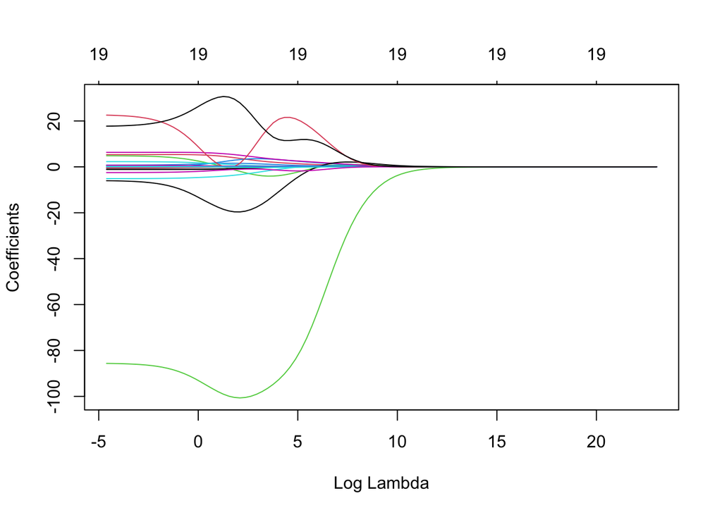

```r
hitters_ridge <- glmnet(x[train, ], y[train], alpha = 0, lambda = grid)
plot(hitters_ridge, xvar = "lambda")
```

- ¿Cuál es el $\lambda$ óptimo? Lo elegimos por **validación cruzada** con `cv.glmnet()`:

```r
set.seed(123)
cv_ridge <- cv.glmnet(x[train, ], y[train], alpha = 0)
bestlam <- cv_ridge$lambda.min
bestlam
```

```
## [1] 27.68026
```

- Ese es el $\lambda$ que minimiza el error de validación cruzada. El modelo asociado es:

```r
predict(cv_ridge, s = bestlam, type = "coefficients")[1:20, ]
```

```
##   (Intercept)         AtBat          Hits         HmRun          Runs
##   5.844324641  -0.241562143   2.373743726  -3.975610051   3.513429692
##           RBI         Walks         Years        CAtBat         CHits
##  -1.922469111   3.831308315 -15.657309139  -0.007812126   0.153939804
##        CHmRun         CRuns          CRBI        CWalks       LeagueN
##   1.221707466   0.420086952   0.222140659  -0.349275055  14.924774733
##     DivisionW       PutOuts       Assists        Errors    NewLeagueN
## -97.393864788   0.108392714  -0.266424720  -1.089488926  16.153677915
```

# 4. Lasso

- El proceso es equivalente, pero con `alpha = 1`. Estimamos sobre el entrenamiento y graficamos:

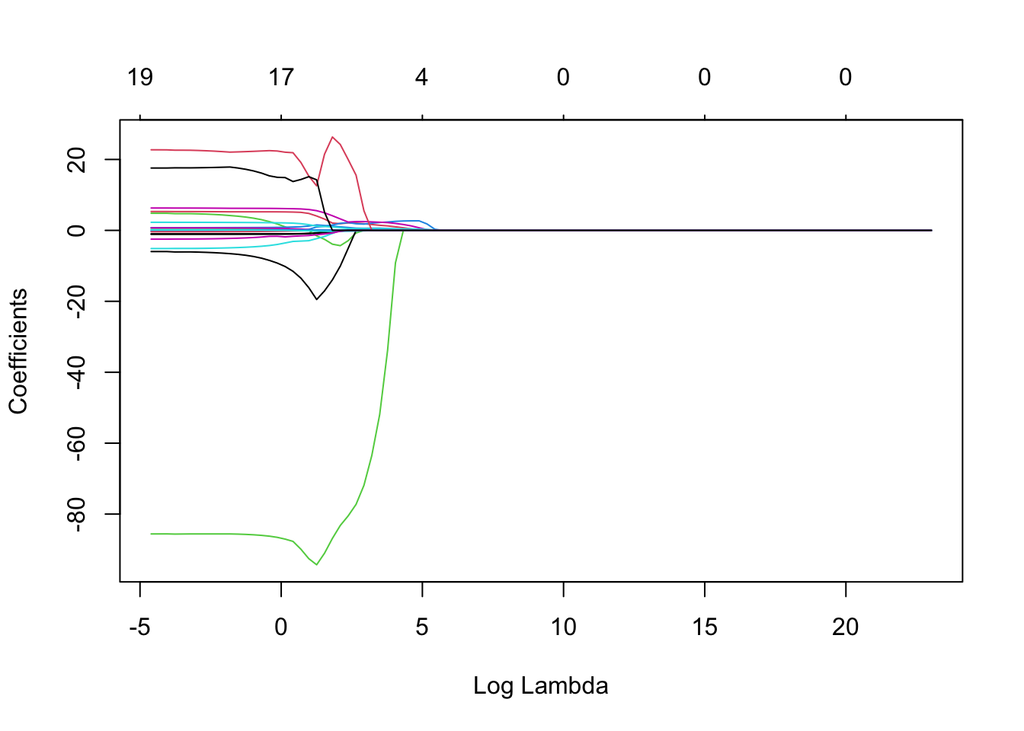

```r
hitters_lasso <- glmnet(x[train, ], y[train], alpha = 1, lambda = grid)
plot(hitters_lasso, xvar = "lambda")
```

- A medida que $\lambda$ crece, los coeficientes caen y algunos se vuelven exactamente 0. Busquemos el $\lambda$ óptimo por validación cruzada:

```r
set.seed(123)
cv_lasso <- cv.glmnet(x[train, ], y[train], alpha = 1)
bestlam <- cv_lasso$lambda.min
bestlam
```

```
## [1] 0.7883439
```

- Y veamos el modelo asociado:

```r
predict(cv_lasso, s = bestlam, type = "coefficients")[1:20, ]
```

```
## (Intercept)       AtBat        Hits       HmRun        Runs         RBI
##  77.3490393  -0.9717104   5.3014281   2.2090518   0.0000000  -4.1860328
##       Walks       Years      CAtBat       CHits      CHmRun       CRuns
##   6.1949584  -8.8408861  -0.2600294   0.2599032   0.7187946   2.1742933
##        CRBI      CWalks     LeagueN   DivisionW     PutOuts     Assists
##   0.6466683  -1.0770956  21.7240855 -86.8843861   0.1471348   0.0000000
##      Errors  NewLeagueN
##  -1.5474059  15.6505652
```